# Projet_sujet6

2023-02-01

# Etude de l’influence de la température et du stade d’imbibition sur la capacité germinative des graines

*Etude de l’influence de la* *température* *(variable qualitative à 3 modalités : `Low`, `Medium` et `Elevated`) et du* *stade d’imbibition* *(variable qualitative à 3 modalités : `DS` (Dry seed), `EI` après 6h d’imbibition (Early imbibition) correspondant à la fin de la prise d’eau, `LI` après 20h d’imbibition (Late imbibition)) sur la* *capacité germinative* *des graines à l’aide de données de métabolomique pour des graines ayant subi un vieillissement artificiel de 4 jours (`CD_4d`)*

**Métabolome** : ensemble complet des petites molécules présentes dans une cellule, un organe ou un organisme à un moment donné.

## 1. Récupération des données

### 1.1 Chargement des données

```r
SEUIL=0.998
```

```r
data = read.table('Table_metabolome_CD_all.csv', sep=';', header=TRUE, dec=",")
dim(data)
```

```
## [1]  54 284
```

```r
#str(data)
head(data[,1:13])
```

```
##         code              sample             group rep temperature imbibition
## 1  DS-HT-NA1 Elevated_DS_CD_0d_1 Elevated_DS_CD_0d   1    Elevated         DS
## 2  DS-HT-NA2 Elevated_DS_CD_0d_2 Elevated_DS_CD_0d   2    Elevated         DS
## 3  DS-HT-NA3 Elevated_DS_CD_0d_3 Elevated_DS_CD_0d   3    Elevated         DS
## 4 DS-STD-NA1   Medium_DS_CD_0d_1   Medium_DS_CD_0d   1      Medium         DS
## 5 DS-STD-NA2   Medium_DS_CD_0d_2   Medium_DS_CD_0d   2      Medium         DS
## 6 DS-STD-NA3   Medium_DS_CD_0d_3   Medium_DS_CD_0d   3      Medium         DS
##   treatment m_a.Aminoadipate m_Alanine m_Arginine m_Asparagine m_Aspartate
## 1     CD_0d       0.02589281 0.5292213 0.00003120    0.9430179   0.5684465
## 2     CD_0d       0.01966366 0.5015054 0.00003120    0.8637622   0.4793713
## 3     CD_0d       0.02420040 0.5145814 0.00003120    1.1309472   0.6782414
## 4     CD_0d       0.03552505 0.5498670 0.00003120    0.8007421   0.3642250
## 5     CD_0d       0.04000785 0.6471823 0.00003120    0.8189125   0.4671479
## 6     CD_0d       0.04010745 0.7370537 0.02006946    0.9466605   0.4883016
##   m_b.aminoisobutyrate
## 1             3.12e-05
## 2             3.12e-05
## 3             3.12e-05
## 4             3.12e-05
## 5             3.12e-05
## 6             3.12e-05
```

### 1.2 Données des graines ayant subi un vieillissement artificiel de 4 jours (`CD_4d`)

```r
levels(factor(data$treatment))
```

```
## [1] "CD_0d" "CD_4d"
```

```r
data_J4 = data[data$treatment=="CD_4d",]
```

### 1.3 Mise en forme des données

On extrait les matrices de données :

```r
len = length(colnames(data_J4))
Y <- as.matrix(data_J4[, 8:len])
X1 <- data_J4$temperature
X2 <- data_J4$imbibition
```

```r
X1 <- factor(as.character(X1))
X2 <- factor(as.character(X2))

table(X1,X2)
```

```
##           X2
## X1         DS EI LI
##   Elevated  3  3  3
##   Low       3  3  3
##   Medium    3  3  3
```

Construction de la matrice de design :

```r
X <- model.matrix(lm(Y ~ X1 + X2 + 0))
p <- ncol(X)
n=nrow(X)
p;n
```

```
## [1] 5
```

```
## [1] 27
```

On réduit Y pour se ramener à une variance (égale ? comparable ?) pour rendre les colonnes comparables : Question d’échelle, ils seront tous du même ordre de grandeur. –> Ne fonctionne pas

```r
'
#Ne fonctionne pas
q=dim(Y)[2]; q
Yscaled=scale(Y); Y=Yscaled
'
```

```
## [1] "\n#Ne fonctionne pas\nq=dim(Y)[2]; q\nYscaled=scale(Y); Y=Yscaled\n"
```

## 2. Analyse descriptive

### 2.1 Informations générales dur les données

```r
#summary(data)
skim(data[,1:13])
```

Data summary

| Name | data[, 1:13] |
| --- | --- |
| Number of rows | 54 |
| Number of columns | 13 |
| _______________________ |  |
| Column type frequency: |  |
| character | 6 |
| numeric | 7 |
| ________________________ |  |
| Group variables | None |

**Variable type: character**

| skim_variable | n_missing | complete_rate | min | max | empty | n_unique | whitespace |
| --- | --- | --- | --- | --- | --- | --- | --- |
| code | 0 | 1 | 8 | 10 | 0 | 54 | 0 |
| sample | 0 | 1 | 14 | 19 | 0 | 54 | 0 |
| group | 0 | 1 | 12 | 17 | 0 | 18 | 0 |
| temperature | 0 | 1 | 3 | 8 | 0 | 3 | 0 |
| imbibition | 0 | 1 | 2 | 2 | 0 | 3 | 0 |
| treatment | 0 | 1 | 5 | 5 | 0 | 2 | 0 |

**Variable type: numeric**

| skim_variable | n_missing | complete_rate | mean | sd | p0 | p25 | p50 | p75 | p100 | hist |
| --- | --- | --- | --- | --- | --- | --- | --- | --- | --- | --- |
| rep | 0 | 1 | 2.00 | 0.82 | 1.00 | 1.00 | 2.00 | 3.00 | 3.00 | ▇▁▇▁▇ |
| m_a.Aminoadipate | 0 | 1 | 0.02 | 0.01 | 0.00 | 0.02 | 0.02 | 0.03 | 0.04 | ▁▂▆▇▂ |
| m_Alanine | 0 | 1 | 0.71 | 0.27 | 0.32 | 0.50 | 0.70 | 0.85 | 1.45 | ▇▆▅▃▁ |
| m_Arginine | 0 | 1 | 0.01 | 0.03 | 0.00 | 0.00 | 0.00 | 0.00 | 0.14 | ▇▁▁▁▁ |
| m_Asparagine | 0 | 1 | 1.06 | 0.38 | 0.44 | 0.77 | 0.94 | 1.43 | 1.83 | ▃▇▂▅▂ |
| m_Aspartate | 0 | 1 | 0.75 | 0.56 | 0.06 | 0.25 | 0.51 | 1.32 | 1.90 | ▇▃▂▃▂ |
| m_b.aminoisobutyrate | 0 | 1 | 0.00 | 0.00 | 0.00 | 0.00 | 0.00 | 0.00 | 0.01 | ▇▁▁▁▁ |

```r
#skim(data[c("temperature", "imbibition", "treatment")])
```

### 2.2 Graphes

#### 2.2.1 Anlayse univariée

Vérifier les 4 **hypothèses du modèle linéaire** pour l’utiliser par la suite :

- Les observations sont distribuées selon une loi Normale $N(0,\sigma^2)$
- La variance des observation est constante (**homoscédasticité**)
- Les variables aléatoires représentant les observations sont **indépendantes**
- La relation entre l’espérance de la variable à expliuer et les variables explicatives est linéaire.

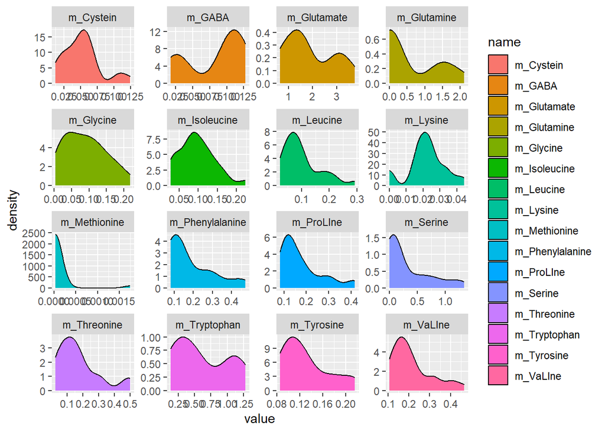

```r
as.data.frame(Y[,8:23]) %>%
  select(where(is.numeric)) %>%
  pivot_longer(cols = everything()) %>%
  ggplot(aes(x = value, fill = name)) +
  geom_density() +
  facet_wrap(~ name, nrow=4, ncol=4, scales = "free")
```

#### 2.2.2 Corrplot et heatmap

Attention données `CD_4d` ou totales:

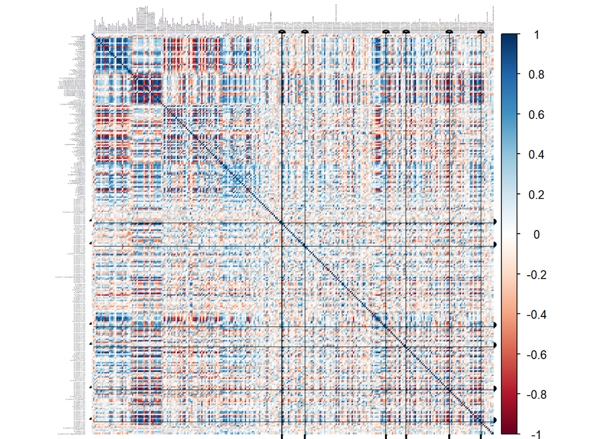

```r
data_J4 %>%
  select(where(is.numeric)) %>%
  cor() %>%
  corrplot(method = "color", tl.col = 'black', tl.cex=0.1)
```

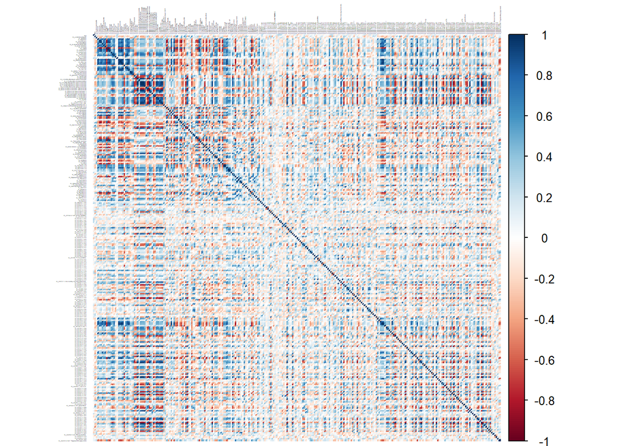

```r
data %>%
  select(where(is.numeric)) %>%
  cor() %>%
  corrplot(method = "color", tl.col = 'black', tl.cex=0.1)
```

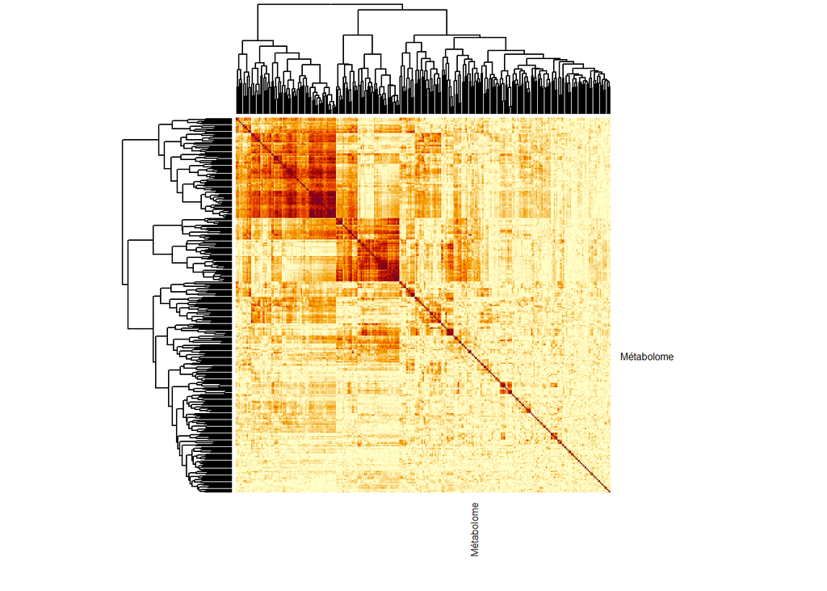

```r
heatmap(abs(cor(data[,8:len])), labRow=c("Métabolome"), labCol=c("Métabolome"), sym=TRUE)
```

Trop de variables, c’est illisible.

#### 2.2.3 Boxplots

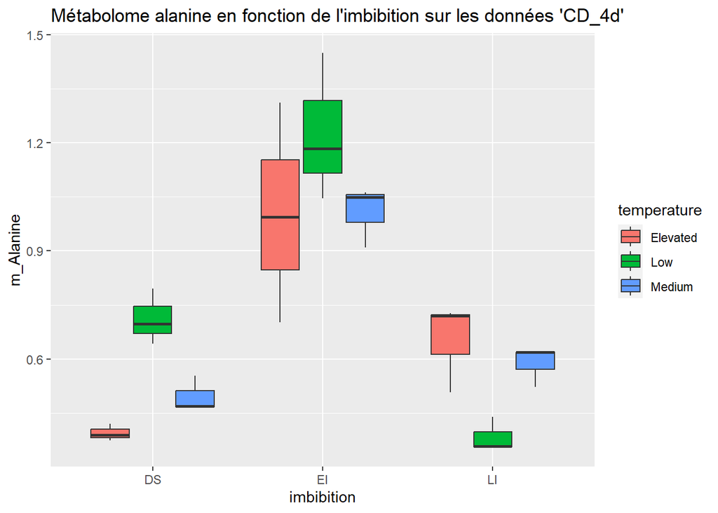

```r
#eval=FALSE
data_J4 %>%
  ggplot(aes(x = imbibition, y = m_Alanine, fill = temperature)) +
  geom_boxplot() +
  ggtitle("Métabolome alanine en fonction de l'imbibition sur les données 'CD_4d'")
```

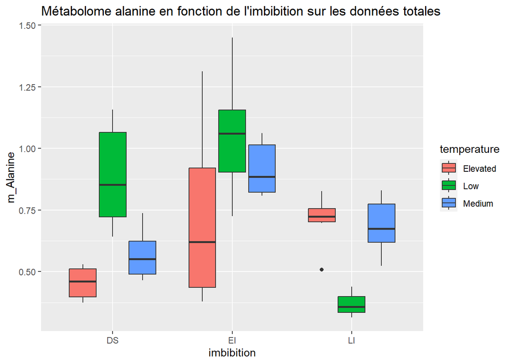

```r
data %>%
  ggplot(aes(x = imbibition, y = m_Alanine, fill = temperature)) +
  geom_boxplot() +
  ggtitle("Métabolome alanine en fonction de l'imbibition sur les données totales")
```

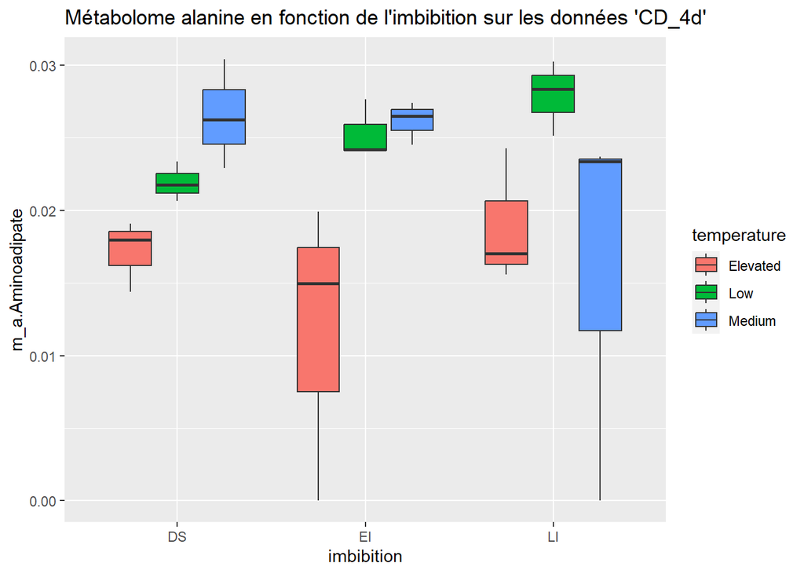

```r
data_J4 %>%
  ggplot(aes(x = imbibition, y = m_a.Aminoadipate, fill = temperature)) +
  geom_boxplot() +
  ggtitle("Métabolome alanine en fonction de l'imbibition sur les données 'CD_4d'")
```

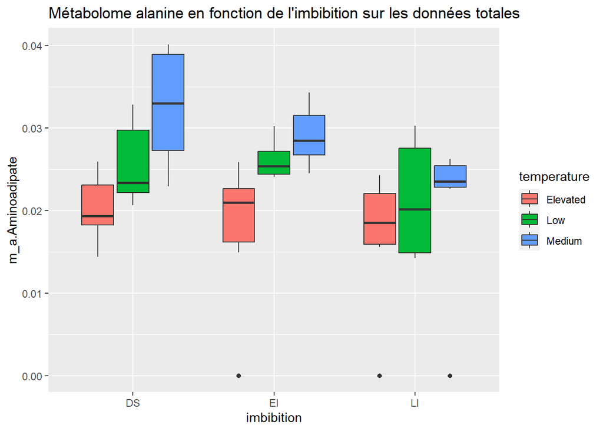

```r
data %>%
  ggplot(aes(x = imbibition, y = m_a.Aminoadipate, fill = temperature)) +
  geom_boxplot() +
  ggtitle("Métabolome alanine en fonction de l'imbibition sur les données totales")
```

### 2.3 ACP

```r
acp.res=PCA(Y, scale.unit=TRUE, ncp=dim(Y)[2], graph=FALSE)

get_eigenvalue(acp.res)
```

```
##        eigenvalue variance.percent cumulative.variance.percent
## Dim.1   71.097499       26.2352395                    26.23524
## Dim.2   48.782731       18.0010076                    44.23625
## Dim.3   24.335045        8.9797213                    53.21597
## Dim.4   15.523521        5.7282363                    58.94420
## Dim.5   13.762968        5.0785859                    64.02279
## Dim.6   11.219441        4.1400150                    68.16281
## Dim.7    9.856341        3.6370262                    71.79983
## Dim.8    7.780722        2.8711152                    74.67095
## Dim.9    7.069378        2.6086264                    77.27957
## Dim.10   6.358310        2.3462398                    79.62581
## Dim.11   5.954732        2.1973181                    81.82313
## Dim.12   5.890307        2.1735451                    83.99668
## Dim.13   5.098847        1.8814935                    85.87817
## Dim.14   4.672880        1.7243101                    87.60248
## Dim.15   4.028776        1.4866332                    89.08911
## Dim.16   3.799482        1.4020228                    90.49114
## Dim.17   3.448032        1.2723365                    91.76347
## Dim.18   3.345565        1.2345259                    92.99800
## Dim.19   3.180352        1.1735615                    94.17156
## Dim.20   3.013751        1.1120851                    95.28364
## Dim.21   2.620278        0.9668921                    96.25054
## Dim.22   2.547407        0.9400027                    97.19054
## Dim.23   2.273209        0.8388227                    98.02936
## Dim.24   2.100436        0.7750685                    98.80443
## Dim.25   1.730299        0.6384868                    99.44292
## Dim.26   1.509693        0.5570823                   100.00000
```

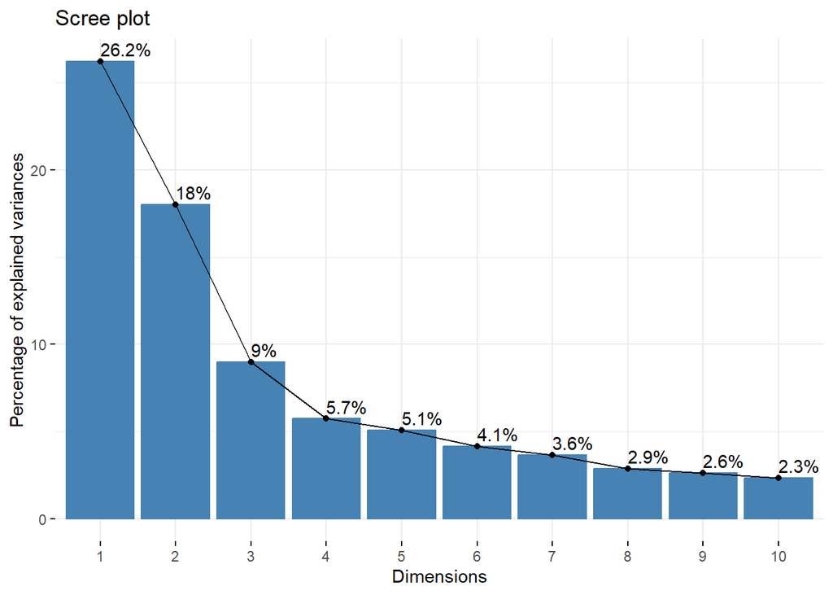

```r
fviz_eig(acp.res, addlabels = TRUE)
```

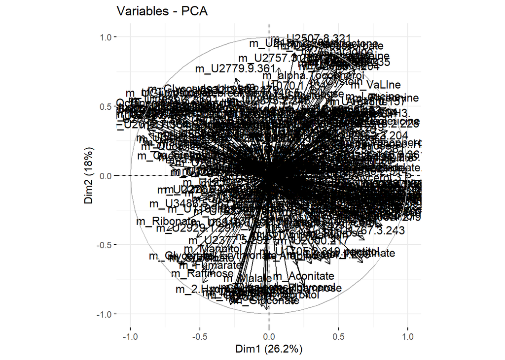

```r
fviz_pca_var(acp.res)
```

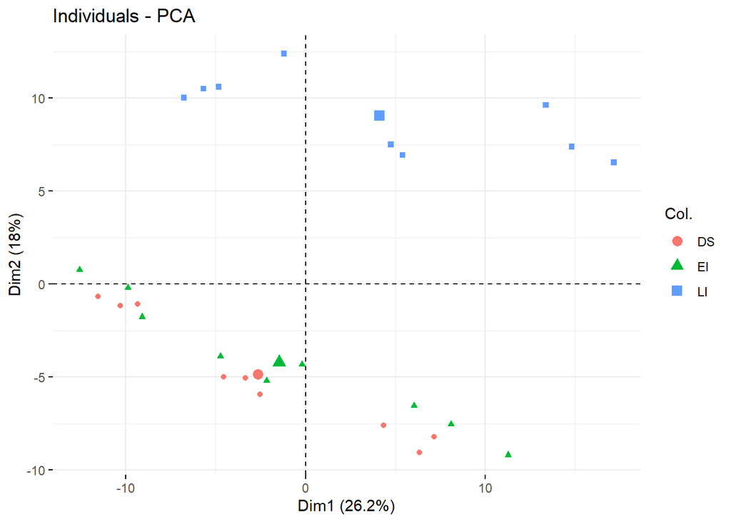

```r
fviz_pca_ind(acp.res, geom.ind="point", col.ind=X2)
```

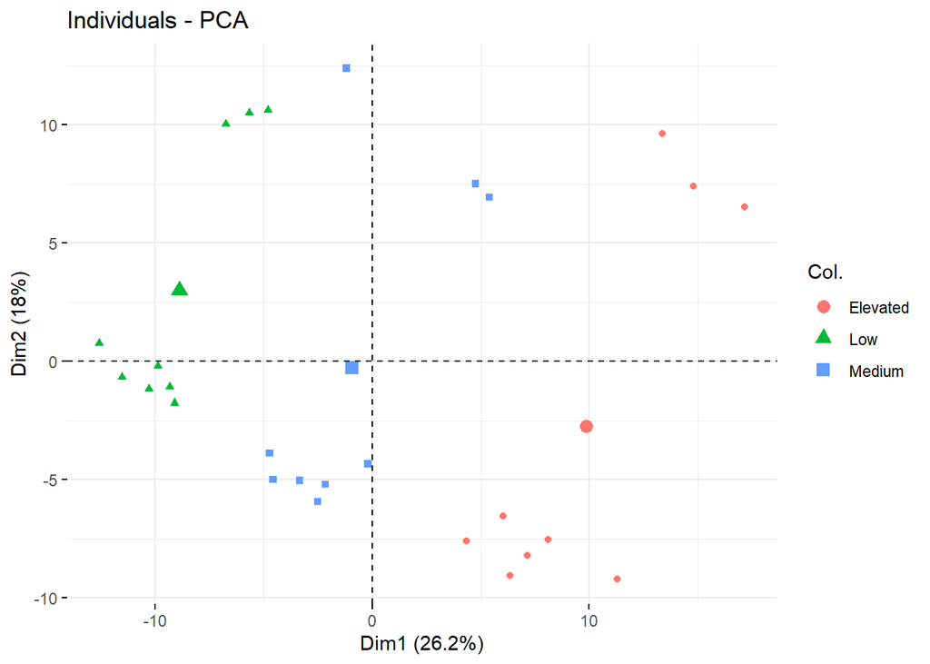

```r
fviz_pca_ind(acp.res, geom.ind="point", col.ind=X1)
```

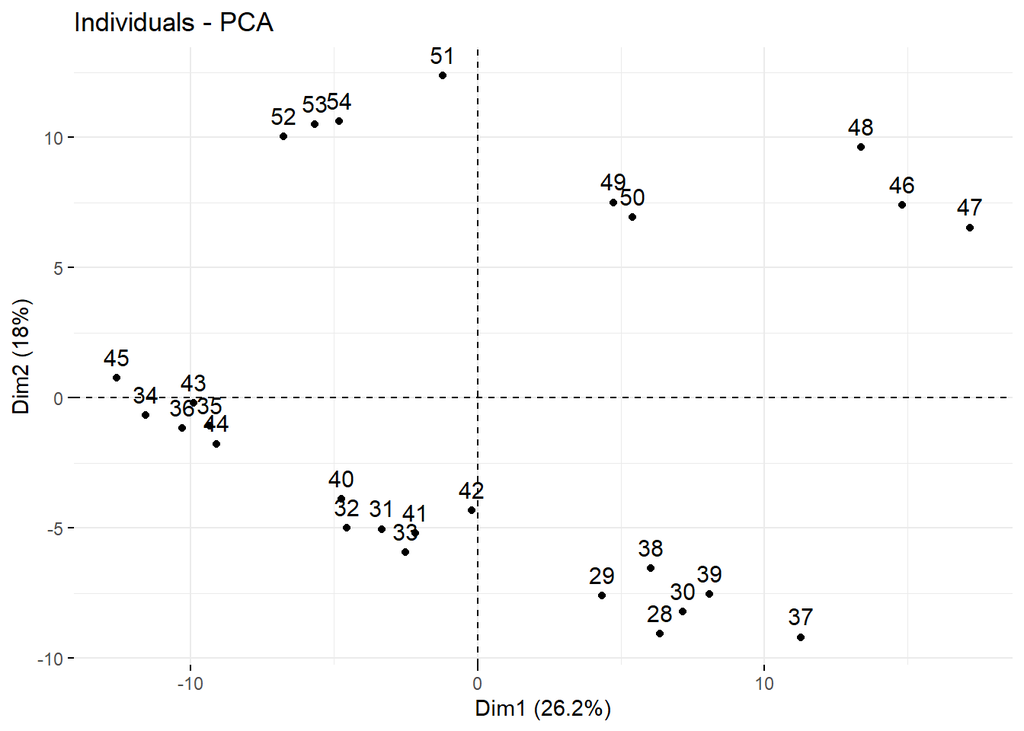

```r
fviz_pca_ind(acp.res, axes=1:2)
```

## 3. Analyse des données de métabolomique pour des graines ayant subi un vieillissement artificiel de 4 jours (`CD_4d`)

Nous sommes dans le cas où le modèle linéaire est défini ainsi :
$$Y=XB+E$$
où:

- $Y=(Y_{ij})_{i \in [1,n], j\ in [1,q]}$ matrice de taille $n$x$q$
- $X$ est la matrice de design de taille $n$x$p$

- $B$ est la matrice de taille $p$x$q$ qui contient les paramètres
- $E$ est une matrice de taille $n$x$q$ telle que :

$~~~~~~~~~~~~~~~$ $\forall i \in [1,n], ~~~ (E_{i,1},...,E_{i,q}) \overset{iid}{\sim} N(0,\sum_q)$

$~~~~~~~$ où $\sum_q$ désigne la matrice de covariance de la i-ème ligne de $E$.

**Notre but :** Estimer $B$ de manière parcimonieuse.

### 3.1 Etape 1: Est ce que les colonnes de Y sont indépendantes ?

#### 3.1.1 Estimation des $Ê_i$

```r
residuals=lm(as.matrix(Y)~X-1)$residuals
```

On fait le test PorteManteau:

```r
pvalue=whitening_test(residuals)
pvalue
```

```
## [1] 0.9646102
```

On devrait obtenir une petite p-value. $Ê_i$ bruit blanc ($H_0$) ou non($H_1$). p_value petite on rejette $H_0$ (avec force) les colonnes ne sont donc pas indépendantes.

**TRAITER DANS LES DEUX CAS COMME SI ON REJETTAIT ET COMME SI ON ACCEPTAIT**

Regarder les métabolites correspondantes